# Homework 2 - Mapping Parking Violations in NYC

YI YIN

2019-02-24

```r
library(tidyverse)
```

# 1. Data exploration

## a) Violation Code and Fine Amounts

```r
# load data into space
parking <-read_csv("parking/parkingNYC_Jan2019.csv")
vio_code <- readxl::read_xlsx("parking/parkingNYC_ParkingViolationCodes_Nov_2018.xlsx")

# rename variable names
colnames(parking)<-stringr::str_replace_all(colnames(parking), " ", "_" )%>%
        stringr::str_to_lower()
colnames(vio_code)<-stringr::str_replace_all(colnames(vio_code), " ", "_" )%>%
        stringr::str_to_lower()

colnames(parking)[5] <-"issue_date_chr"

vio_code <-vio_code%>%
        rename(fine_amount_b96=`manhattan__96th_st._&_below\r\n(fine_amount_$)`)%>%
        rename(fine_amount_other = `all_other_areas\r\n(fine_amount_$)`)
```

```r
# Add the violation code descriptions and fine amounts to the data file.
data <- left_join(parking, vio_code, by="violation_code")


data <-data%>%select(-`violation_description.x`)%>%
        rename(violation_description=`violation_description.y`)
```

Provide a visual overview of the top 10 most common types of violations

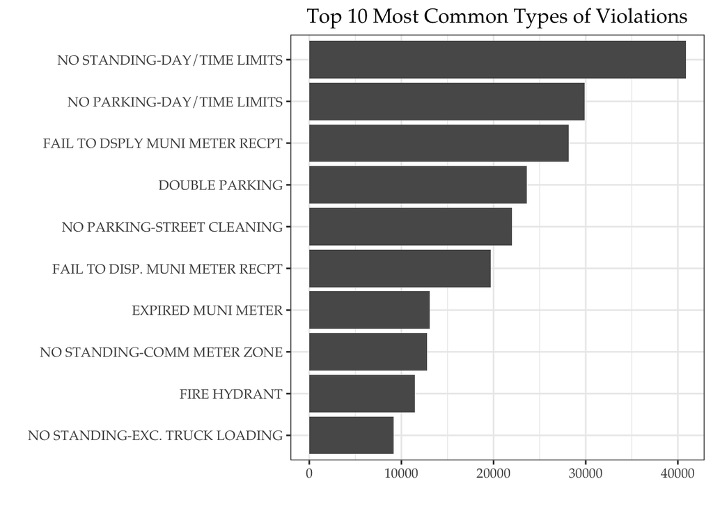

```r
vio_type <- data%>%
        select(violation_description)%>%
        group_by(violation_description)%>%
        summarise(count = n())

vio_type%>%
        top_n(10, count)%>%
        ggplot(aes(y= count, x=reorder(violation_description, count)))+
        geom_bar(stat = "identity")+coord_flip()+
        labs(title = "Top 10 Most Common Types of Violations",
             x="", y="")+
        theme_bw(base_size = 12, base_family = "Palatino")+
        theme(plot.title = element_text(hjust = 0.5))
```

Compare how this ranking differs if we focus on the total amount of revenue generated.

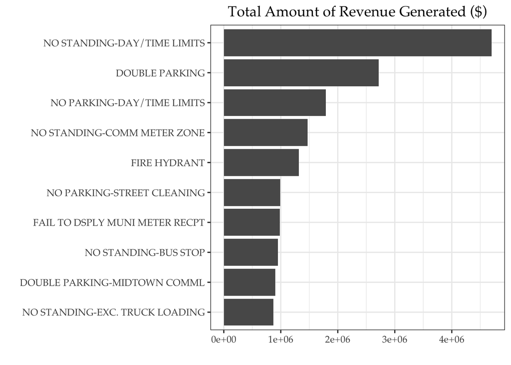

```r
revenue <- data%>%
        select(violation_description, fine_amount_other)%>%
        group_by(violation_description)%>%
        summarise(rev = sum(fine_amount_other))

revenue%>%
        top_n(10, rev)%>%
        ggplot(aes(y= rev, x=reorder(violation_description, rev)))+
        geom_bar(stat = "identity")+coord_flip()+
        labs(title = "Total Amount of Revenue Generated ($)",
             x="", y="")+
        theme_bw(base_size = 12, base_family = "Palatino")+
        theme(plot.title = element_text(hjust = 0.5))
```

## b) Average amount of fine by vehicle

Compare the average amount of fine by vehicle color, vehicle year, and vehicle plate type [Hint: it is sufficient to restrict your attention to commercial (COM) and passenger (PAS) vehicles]? Briefly describe your findings.

```r
# plate_type
data%>%filter(plate_type %in% c("COM","PAS"))%>%
        select(plate_type, fine_amount_other)%>%
        group_by(plate_type)%>%
        summarise(avg = sum(fine_amount_other, na.rm = T)/n())
```

| plate_type | avg |
| --- | --- |
| COM | 79.82381 |
| PAS | 78.56644 |

```r
# vehicle_color
data%>%select(vehicle_color, fine_amount_other)%>%
        group_by(vehicle_color)%>%
        summarise(avg = sum(fine_amount_other, na.rm = T)/n())%>%
        arrange(desc(avg))
```

| vehicle_color | avg |
| --- | --- |
| B | 115.00000 |
| BRN | 115.00000 |
| BRO | 115.00000 |
| BRWN | 115.00000 |
| BWN | 115.00000 |
| DKM | 115.00000 |
| FR | 115.00000 |
| GLD | 115.00000 |
| GRA | 115.00000 |
| GREE | 115.00000 |

[output cut: 107 more lines]

```r
# vehicle_year
data%>%select(vehicle_year, fine_amount_other)%>%
        group_by(vehicle_year)%>%
        summarise(avg = sum(fine_amount_other, na.rm = T)/n())%>%
        arrange(desc(avg))
```

| vehicle_year | avg |
| --- | --- |
| 1993 | 95.44444 |
| 1990 | 94.78395 |
| 1988 | 92.48705 |
| 1997 | 92.02408 |
| 1986 | 90.02857 |
| 1983 | 90.00000 |
| 2020 | 89.00000 |
| 1992 | 86.94639 |
| 1987 | 86.71053 |
| 1995 | 86.50131 |

[output cut: 40 more lines]

# 2. Map by Precincts

Read in the shape files for the police precincts and remove all precincts outside of Manhattan.

```r
library(rgdal)
library(sp)
nypp <-readOGR("police_precincts/.","nypp")
# remove all precincts outside of Manhattan.
nypp_m <- subset(nypp, nypp@data$Precinct%in%c(1:39))

rm(nypp)
```

## a) Number of tickets, total fines, and average fines

Provide three maps that show choropleth maps of:

```r
library(tmap)
layout <- tm_layout(
          legend.title.size = 1,
          legend.text.size = 0.6,
          legend.position = c(0.8,0),
          legend.bg.color = "white",
          legend.bg.alpha = 1,
          bg.color="white",
          frame=FALSE)

ticket <- data%>%
        select(violation_code, violation_precinct)%>%
        rename(Precinct=violation_precinct)%>%
        filter(Precinct<40)%>%
        group_by(Precinct)%>%
        summarise(ticket_n = n())

ny_ti <-sp::merge(nypp_m, ticket, by = "Precinct")

palb <- RColorBrewer::brewer.pal(6,'GnBu')
tm1<-tm_shape(ny_ti) + layout +
        tm_borders()+
        tm_fill("ticket_n", palette=palb,
                title = "Total Number of Tickets by Precinct")
```

```r
total<-data%>%select(fine_amount_other, violation_precinct)%>%
        rename(Precinct=violation_precinct)%>%
        filter(Precinct<40)%>%
        group_by(Precinct)%>%
        summarise(total_amount = sum(fine_amount_other, na.rm = T))

ny_total <-sp::merge(nypp_m, total, by = "Precinct")

palp <- RColorBrewer::brewer.pal(6,'RdPu')

tm2<-tm_shape(ny_total) + layout +
        tm_borders()+
        tm_fill("total_amount", palette=palp,
                title = "Total Amount of Fines by Precinct")
```

```r
avg_f<-data%>%select(fine_amount_other,
                     violation_precinct)%>%
        rename(Precinct=violation_precinct)%>%
        filter(Precinct<40)%>%
        group_by(Precinct)%>%
        summarise(avg_amount = sum(fine_amount_other, na.rm = T)/n())

ny_avg <-sp::merge(nypp_m, avg_f, by = "Precinct")

paly <- RColorBrewer::brewer.pal(6,'YlOrBr')

tm3<-tm_shape(ny_avg) + layout +
        tm_borders()+
        tm_fill("avg_amount", palette=paly,
                title = "Average Amount of Fines by Precinct")
```

- the total number of tickets

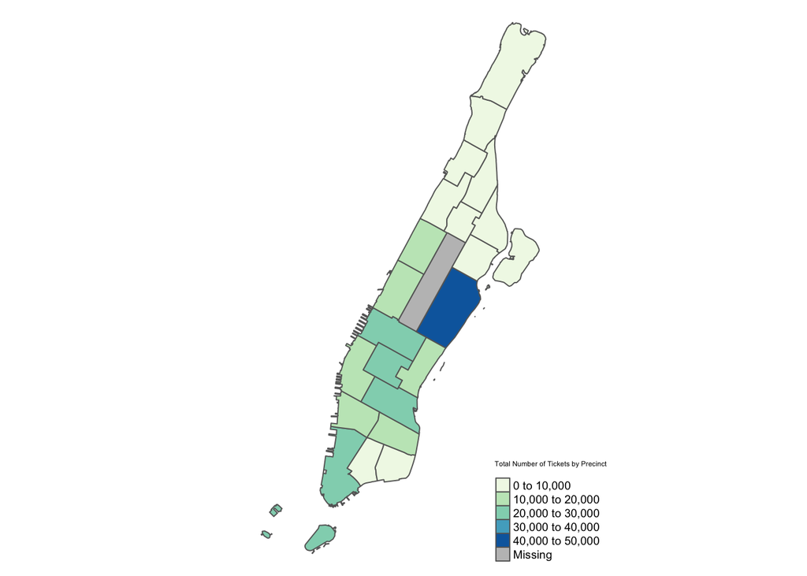

```r
tm1
```

- the total amount of fines

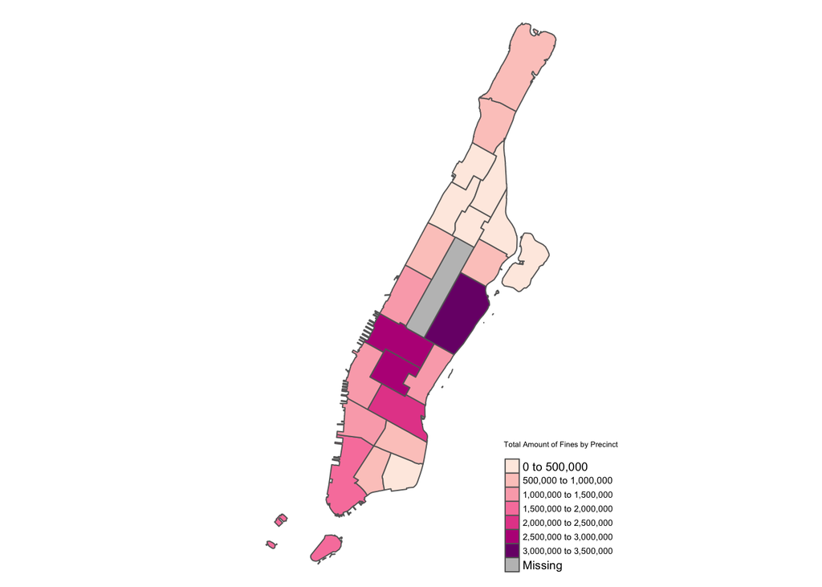

```r
tm2
```

- the average amount of fines

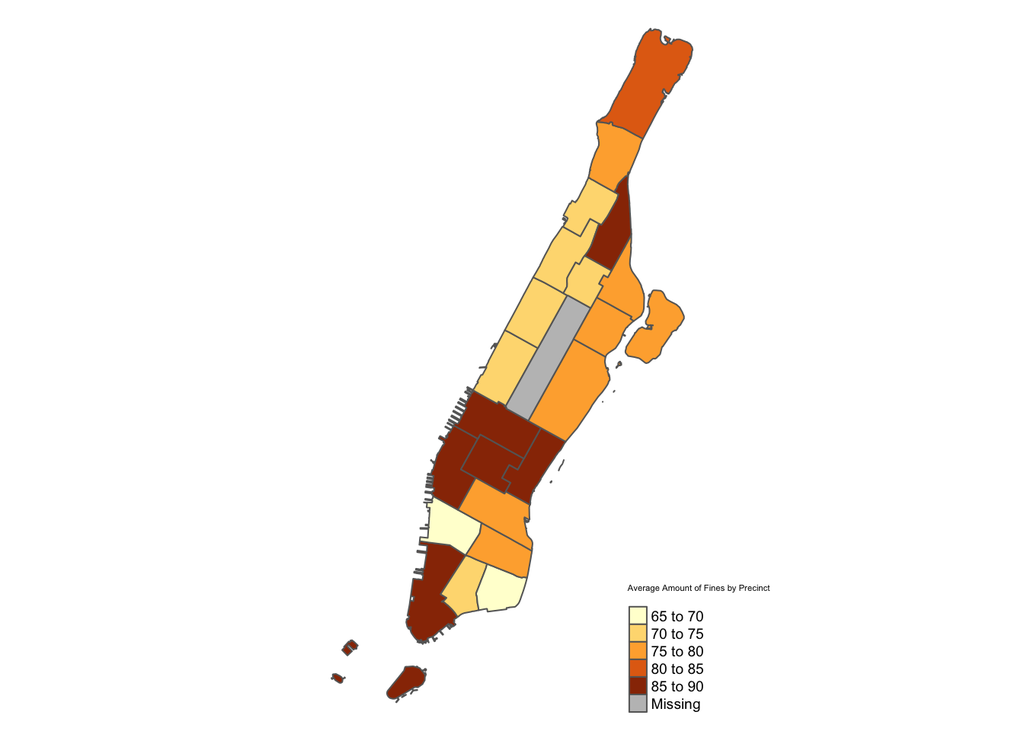

```r
tm3
```

Briefly describe what you learn from these maps in comparison.

Upper east side has the highest total number of tickets, and total amount of fines. While Midtown has the highest average amount of fines.

## b) Types of violations

Group the almost 100 types of ticket violations into a smaller set of 4-6 subgroups

Provide choropleth maps for each of these subgroups to show where different types of violations are more or less common.

```r
viogroup <- data%>%select(violation_description,violation_precinct)

library(stringr)
viogroup$newg <-case_when(str_detect(viogroup$violation_description,
                                              "NO STAND") ~ "NO_STAND",
                          str_detect(viogroup$violation_description,
                                              "NO PARKING") ~ "NO PARKING",
                          str_detect(viogroup$violation_description,
                                              "MISSING") ~ "MISSING",
                          str_detect(viogroup$violation_description,
                                              "FAIL TO") ~ "FAIL TO",
                          TRUE ~ "Other")
```

```r
FAIL<-viogroup%>%
        rename(Precinct=violation_precinct)%>%
        filter(Precinct<40, newg =="FAIL TO")%>%
        group_by(Precinct)%>%
        summarise(tot = n())

ny_FAIL <-sp::merge(nypp_m, FAIL, by = "Precinct")

tm4<-tm_shape(ny_FAIL) + layout +
        tm_borders()+
        tm_fill("tot", palette=palb,
                title = "Fail to do sth")
```

```r
MISSING<-viogroup%>%
        rename(Precinct=violation_precinct)%>%
        filter(Precinct<40, newg =="MISSING")%>%
        group_by(Precinct)%>%
        summarise(tot = n())

ny_MISSING <-sp::merge(nypp_m, MISSING, by = "Precinct")

tm5<-tm_shape(ny_MISSING) + layout +
        tm_borders()+
        tm_fill("tot", palette=palp,
                title = "Missing sth")
```

```r
PARKING<-viogroup%>%
        rename(Precinct=violation_precinct)%>%
        filter(Precinct<40, newg =="NO PARKING")%>%
        group_by(Precinct)%>%
        summarise(tot = n())

ny_PARKING <-sp::merge(nypp_m, PARKING, by = "Precinct")

tm6<-tm_shape(ny_PARKING) + layout +
        tm_borders()+
        tm_fill("tot", palette=paly,
                title = "No Parking")



STAND<-viogroup%>%
        rename(Precinct=violation_precinct)%>%
        filter(Precinct<40, newg =="NO_STAND")%>%
        group_by(Precinct)%>%
        summarise(tot = n())

ny_STAND <-sp::merge(nypp_m, STAND, by = "Precinct")

palyg <- RColorBrewer::brewer.pal(6,'YlGn')

tm7<-tm_shape(ny_STAND) + layout +
        tm_borders()+
        tm_fill("tot", palette=palyg,
                title = "No Stand")
```

Four main groups:

- NO STAND
- NO PARKING
- MISSING
- FAIL TO

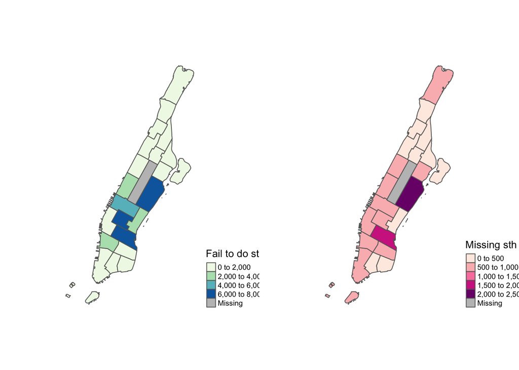

```r
tmap_arrange(tm4, tm5, asp = 1)
```

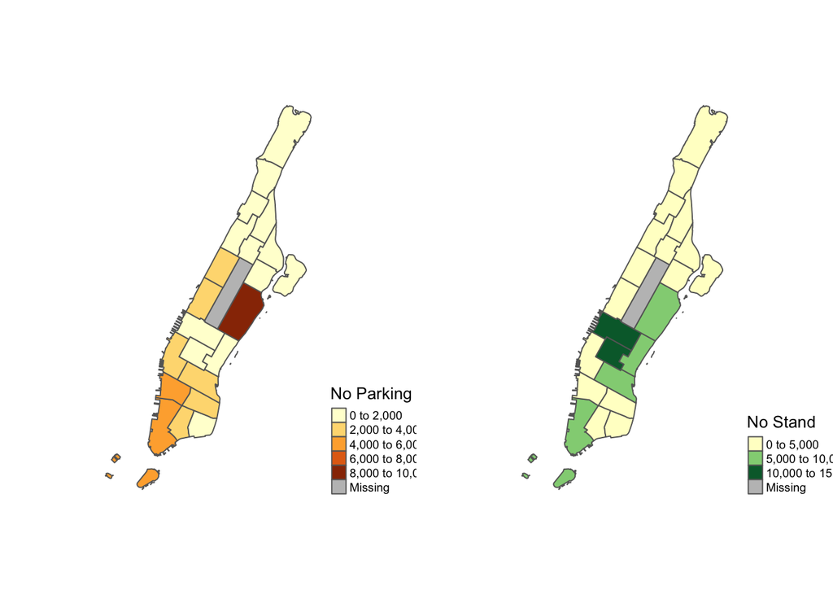

```r
tmap_arrange(tm6, tm7, asp = 1)
```

# 3. Focus on the Upper East

## a) Ignoring fire hydrants

geocode at least 500 addresses

```r
upper_east <- data%>%filter(violation_precinct==19 & violation_code==40)

library(ggmap)
upper_east500 <-upper_east%>%select(street_name,
                              house_number,
                              vehicle_make,
                              issue_date)%>%
        mutate(address = paste(street_name, house_number,
                               "New York, NY"))%>%
        select(-house_number)%>%
        sample_n(500)

upper_east500<-upper_east500%>%mutate_geocode(address)
```

Include a data table of these addresses and the latitude and longitude of these addresses in the output.

```r
adtable<-upper_east500%>%select(address,lat, lon)
adtable
```

| address | lat | lon |
| --- | --- | --- |
| E 88th St 439 New York, NY | 40.77772 | -73.94696 |
| E 64th St N New York, NY | 40.76469 | -73.96431 |
| Lexington Ave 1517 New York, NY | 40.78697 | -73.94978 |
| E 91st St 301 New York, NY | 40.78102 | -73.94906 |
| 3rd Ave 1270 New York, NY | 40.77067 | -73.96020 |
| Park Ave E New York, NY | 40.80500 | -73.93888 |
| E 87th St 125 New York, NY | 40.78052 | -73.95543 |
| E 91st St 319 New York, NY | 40.78083 | -73.94808 |
| 3rd Ave 1474 New York, NY | 40.77723 | -73.95550 |
| E 87th St 528 New York, NY | 40.77596 | -73.94550 |

[output cut: 490 more lines]

## b) Interactive Map

Provide an interactive map of the violations you geocoded using leaflet. Provide at least three pieces of information on the parking ticket in a popup.

```r
library(leaflet)
m<-leaflet(upper_east500) %>%
  addTiles() %>%
  addCircles(lng = ~lon, lat = ~lat)



content <- paste("Location:",upper_east500$street_name,"<br/>",
                 "Vehicle Brand:",upper_east500$vehicle_make,"<br/>",
                 "Date:",upper_east500$issue_date,"<br/>")

m %>% addCircles(popup = content) %>%
        setView(-73.95422, 40.77517,
                zoom = 14)
```

[interactive chart not shown]

## c) Luxury cars and repeat offenders

Using the vehicle Plate ID, identify repeat offenders (in the full dataset).

```r
repeat_off <-data%>%mutate(
        repeat_f = ifelse(duplicated(plate_id)==T, "Yes", "No"),
        luxury_c = ifelse(vehicle_make %in% c('BMW',
                                              'FERRA',
                                              'ROLLS',
                                              'PORSC',
                                              'BENTL',
                                              'JAGUA',
                                              'LEXUS'), "Yes", "No"))%>%
        filter(violation_precinct==19 & violation_code==40)%>%
        select(street_name, house_number,vehicle_make,issue_date,
               repeat_f,luxury_c)%>%
        mutate(address = paste(street_name, house_number,
                               "New York, NY"))%>%
        select(-house_number)%>%
        sample_n(500)
```

Start with the previous map. Distinguish the points by whether the car is a repeat offender and/or luxury car. Add a legend informing the user about the color scheme.

```r
repeat_off<-repeat_off%>%mutate_geocode(address)
```

Also make sure that the added information about the car type and repeat offender status is now contained in the popup information. Show this map.

```r
r<-leaflet(repeat_off) %>%
  addTiles() %>%
  addCircles(lng = ~lon, lat = ~lat)



content_r <- paste("Location:",repeat_off$street_name,"<br/>",
                 "Vehicle Brand:",repeat_off$vehicle_make,"<br/>",
                 "Date:",repeat_off$issue_date,"<br/>",
                 "Luxury Car:", repeat_off$luxury_c,"<br/>")

library(RColorBrewer)
pal = colorFactor("Set1", domain =repeat_off$repeat_f)
color_offsel1 = pal(repeat_off$repeat_f)



r %>% addCircles(color = color_offsel1,  popup = content_r) %>%
  addLegend(pal = pal, values = ~repeat_off$repeat_f,
            title = "Repeated Offender")%>%
        setView(-73.95422, 40.77517, zoom = 14)
```

[interactive chart not shown]

## d) Cluster

```r
r%>%addCircleMarkers(color = color_offsel1,
                       popup = content,
                       clusterOptions = markerClusterOptions())%>%
        addLegend(pal = pal, values = ~repeat_off$repeat_f,
            title = "Repeated Offender")%>%
        setView(-73.95422, 40.77517, zoom = 15)
```

[interactive chart not shown]